# Section 3 Report

Michael Masterson

13 August, 2020

Useful keyboard shortcuts:

- control (command) + shift + enter runs entire code chunk
- control (command) + alt (option) + p runs all chunks above. This is useful for catching up if you needed to restart R.

# Function Arguments

You can either give arguments to a function by name, such as argument_name = value, or you can just give the value in the order that the function expects. If you give your arguement by order, make sure you supply the arguments in the correct order! Let’s see how this works with the seq() function below.

```r
?seq


seq(1, 10, 1)
```

```
##  [1]  1  2  3  4  5  6  7  8  9 10
```

```r
# is different than:
# seq(10, 1, 1) # try uncommenting this line and see what happens

# Whereas when you specify by name, you can place the arguments in any order
seq(to = 10, from = 1 , by = 1)
```

```
##  [1]  1  2  3  4  5  6  7  8  9 10
```

```r
# Mixing and matching specifying by name and order will work but you should avoid it
# and try to be consistent
seq(1, by = 1, 10)
```

```
##  [1]  1  2  3  4  5  6  7  8  9 10
```

# count()

Remember distinct(), which tells you all the values a variable takes?

```r
distinct(gapminder, continent)
```

```
## # A tibble: 5 x 1
##   continent
##   <fct>
## 1 Asia
## 2 Europe
## 3 Africa
## 4 Americas
## 5 Oceania
```

Compare it to count(), which gives you the number of times a variable takes a particular value. Just like distinct, the first argument is the dataframe and the second argument is the variable. This is a common format for tidyverse functions and most of the functions we will learn today take these arguments.

```r
count(gapminder, continent)
```

```
## # A tibble: 5 x 2
##   continent     n
##   <fct>     <int>
## 1 Africa      624
## 2 Americas    300
## 3 Asia        396
## 4 Europe      360
## 5 Oceania      24
```

```r
# table(gapminder$continent)


# or

count(gapminder, country)
```

```
## # A tibble: 142 x 2
##    country         n
##    <fct>       <int>
##  1 Afghanistan    12
##  2 Albania        12
##  3 Algeria        12
##  4 Angola         12
##  5 Argentina      12
##  6 Australia      12
##  7 Austria        12
##  8 Bahrain        12
##  9 Bangladesh     12
## 10 Belgium        12
## # … with 132 more rows
```

# select()

select() chooses a particular variable from a dataframe.

If we want to do something with year we can:

```r
select(gapminder, year)
```

```
## # A tibble: 1,704 x 1
##     year
##    <int>
##  1  1952
##  2  1957
##  3  1962
##  4  1967
##  5  1972
##  6  1977
##  7  1982
##  8  1987
##  9  1992
## 10  1997
## # … with 1,694 more rows
```

Simularly for population:

```r
select(gapminder, pop)
```

```
## # A tibble: 1,704 x 1
##         pop
##       <int>
##  1  8425333
##  2  9240934
##  3 10267083
##  4 11537966
##  5 13079460
##  6 14880372
##  7 12881816
##  8 13867957
##  9 16317921
## 10 22227415
## # … with 1,694 more rows
```

Like many tidyverse functions, select outputs a dataframe. We can use select to make a smaller version of our dataframe that only includes country, year and pop.

```r
smaller.dataframe <- select(gapminder, country, year, pop)

#lets see it
smaller.dataframe
```

```
## # A tibble: 1,704 x 3
##    country      year      pop
##    <fct>       <int>    <int>
##  1 Afghanistan  1952  8425333
##  2 Afghanistan  1957  9240934
##  3 Afghanistan  1962 10267083
##  4 Afghanistan  1967 11537966
##  5 Afghanistan  1972 13079460
##  6 Afghanistan  1977 14880372
##  7 Afghanistan  1982 12881816
##  8 Afghanistan  1987 13867957
##  9 Afghanistan  1992 16317921
## 10 Afghanistan  1997 22227415
## # … with 1,694 more rows
```

You can also specify a variable you want to exclude using -. Lets make a dataframe without the continent variable but including all other variables.

```r
no_continent.data <- select(gapminder, - continent)

#let's see it
no_continent.data
```

```
## # A tibble: 1,704 x 5
##    country      year lifeExp      pop gdpPercap
##    <fct>       <int>   <dbl>    <int>     <dbl>
##  1 Afghanistan  1952    28.8  8425333      779.
##  2 Afghanistan  1957    30.3  9240934      821.
##  3 Afghanistan  1962    32.0 10267083      853.
##  4 Afghanistan  1967    34.0 11537966      836.
##  5 Afghanistan  1972    36.1 13079460      740.
##  6 Afghanistan  1977    38.4 14880372      786.
##  7 Afghanistan  1982    39.9 12881816      978.
##  8 Afghanistan  1987    40.8 13867957      852.
##  9 Afghanistan  1992    41.7 16317921      649.
## 10 Afghanistan  1997    41.8 22227415      635.
## # … with 1,694 more rows
```

# arrange()

arrange puts a dataframe in order from least to greatest If we want to see the dataset from lowest population to highest we can:

```r
arrange(gapminder, pop)
```

```
## # A tibble: 1,704 x 6
##    country               continent  year lifeExp   pop gdpPercap
##    <fct>                 <fct>     <int>   <dbl> <int>     <dbl>
##  1 Sao Tome and Principe Africa     1952    46.5 60011      880.
##  2 Sao Tome and Principe Africa     1957    48.9 61325      861.
##  3 Djibouti              Africa     1952    34.8 63149     2670.
##  4 Sao Tome and Principe Africa     1962    51.9 65345     1072.
##  5 Sao Tome and Principe Africa     1967    54.4 70787     1385.
##  6 Djibouti              Africa     1957    37.3 71851     2865.
##  7 Sao Tome and Principe Africa     1972    56.5 76595     1533.
##  8 Sao Tome and Principe Africa     1977    58.6 86796     1738.
##  9 Djibouti              Africa     1962    39.7 89898     3021.
## 10 Sao Tome and Principe Africa     1982    60.4 98593     1890.
## # … with 1,694 more rows
```

If instead we want greatest to least we can add the desc() function around our variable (for descending order).

```r
arrange(gapminder, desc(pop))
```

```
## # A tibble: 1,704 x 6
##    country continent  year lifeExp        pop gdpPercap
##    <fct>   <fct>     <int>   <dbl>      <int>     <dbl>
##  1 China   Asia       2007    73.0 1318683096     4959.
##  2 China   Asia       2002    72.0 1280400000     3119.
##  3 China   Asia       1997    70.4 1230075000     2289.
##  4 China   Asia       1992    68.7 1164970000     1656.
##  5 India   Asia       2007    64.7 1110396331     2452.
##  6 China   Asia       1987    67.3 1084035000     1379.
##  7 India   Asia       2002    62.9 1034172547     1747.
##  8 China   Asia       1982    65.5 1000281000      962.
##  9 India   Asia       1997    61.8  959000000     1459.
## 10 China   Asia       1977    64.0  943455000      741.
## # … with 1,694 more rows
```

So far we have just printed the dataframe to the console in different orders. If we actually want our dataframe to stay in this order, then we need to save over it.

```r
gapminder <-arrange(gapminder, desc(pop))

gapminder
```

```
## # A tibble: 1,704 x 6
##    country continent  year lifeExp        pop gdpPercap
##    <fct>   <fct>     <int>   <dbl>      <int>     <dbl>
##  1 China   Asia       2007    73.0 1318683096     4959.
##  2 China   Asia       2002    72.0 1280400000     3119.
##  3 China   Asia       1997    70.4 1230075000     2289.
##  4 China   Asia       1992    68.7 1164970000     1656.
##  5 India   Asia       2007    64.7 1110396331     2452.
##  6 China   Asia       1987    67.3 1084035000     1379.
##  7 India   Asia       2002    62.9 1034172547     1747.
##  8 China   Asia       1982    65.5 1000281000      962.
##  9 India   Asia       1997    61.8  959000000     1459.
## 10 China   Asia       1977    64.0  943455000      741.
## # … with 1,694 more rows
```

## When should you write over your data?

Only save over your dataframe when you are sure what you want to do will work. If you mess up your original dataframe, then you will have to load it again and start over. If you want, you can first check the results of your command by assigning the results to a new object.

Never overwrite the original file on your computer the data comes from! You do not need to worry about this too much yet, because we have not learned how to do this. However, keep this warning in mind for later. Instead of overwriting the original, save a new file of the transformed data and hang on to the code you used to transform it.

# Mutate()

We can create a new variable with the mutate command and then save the dataset over our data that includes the new variable using the assignment operator <-.

Like select, mutate’s first argument is the dataframe. Unlike select, its second argument is the name of your *new_variable* = (some function).

If we want to make a gdp variable my multiplying gdp per capita by population we can:

```r
#remember to save the new dataframe over itself with <- or your new variable will not be saved!

gapminder <- mutate(gapminder,
                  gdp = gdpPercap*pop
                  )

#lets see if it is there
gapminder
```

```
## # A tibble: 1,704 x 7
##    country continent  year lifeExp        pop gdpPercap     gdp
##    <fct>   <fct>     <int>   <dbl>      <int>     <dbl>   <dbl>
##  1 China   Asia       2007    73.0 1318683096     4959. 6.54e12
##  2 China   Asia       2002    72.0 1280400000     3119. 3.99e12
##  3 China   Asia       1997    70.4 1230075000     2289. 2.82e12
##  4 China   Asia       1992    68.7 1164970000     1656. 1.93e12
##  5 India   Asia       2007    64.7 1110396331     2452. 2.72e12
##  6 China   Asia       1987    67.3 1084035000     1379. 1.49e12
##  7 India   Asia       2002    62.9 1034172547     1747. 1.81e12
##  8 China   Asia       1982    65.5 1000281000      962. 9.63e11
##  9 India   Asia       1997    61.8  959000000     1459. 1.40e12
## 10 China   Asia       1977    64.0  943455000      741. 6.99e11
## # … with 1,694 more rows
```

What about if I want a log GDP per capita variable?

```r
gapminder<-mutate(gapminder,
                  ln_gdpPercap = log(gdpPercap))

#lets see it
gapminder
```

```
## # A tibble: 1,704 x 8
##    country continent  year lifeExp       pop gdpPercap     gdp ln_gdpPercap
##    <fct>   <fct>     <int>   <dbl>     <int>     <dbl>   <dbl>        <dbl>
##  1 China   Asia       2007    73.0    1.32e9     4959. 6.54e12         8.51
##  2 China   Asia       2002    72.0    1.28e9     3119. 3.99e12         8.05
##  3 China   Asia       1997    70.4    1.23e9     2289. 2.82e12         7.74
##  4 China   Asia       1992    68.7    1.16e9     1656. 1.93e12         7.41
##  5 India   Asia       2007    64.7    1.11e9     2452. 2.72e12         7.80
##  6 China   Asia       1987    67.3    1.08e9     1379. 1.49e12         7.23
##  7 India   Asia       2002    62.9    1.03e9     1747. 1.81e12         7.47
##  8 China   Asia       1982    65.5    1.00e9      962. 9.63e11         6.87
##  9 India   Asia       1997    61.8    9.59e8     1459. 1.40e12         7.29
## 10 China   Asia       1977    64.0    9.43e8      741. 6.99e11         6.61
## # … with 1,694 more rows
```

# Practice 1

1. Add a new variable to the gapminder dataset that is the log of population. Do not forget to save the new version of the gapminder dataset that includes the variable over the old version!
2. Create a new dataset called new.data that includes all of the variables in gapminder except pop.
3. Put new.data in order from greatest to least ln_gdpPercap and save the new.data object in that order.

```r
gapminder <- mutate(gapminder,
                    ln_pop = log(pop))


new.data <- select(gapminder, - pop)

new.data <- arrange(new.data, desc(ln_gdpPercap))
new.data
```

```
## # A tibble: 1,704 x 8
##    country  continent  year lifeExp gdpPercap       gdp ln_gdpPercap ln_pop
##    <fct>    <fct>     <int>   <dbl>     <dbl>     <dbl>        <dbl>  <dbl>
##  1 Kuwait   Asia       1957    58.0   113523.   2.42e10         11.6   12.3
##  2 Kuwait   Asia       1972    67.7   109348.   9.21e10         11.6   13.6
##  3 Kuwait   Asia       1952    55.6   108382.   1.73e10         11.6   12.0
##  4 Kuwait   Asia       1962    60.5    95458.   3.42e10         11.5   12.8
##  5 Kuwait   Asia       1967    64.6    80895.   4.65e10         11.3   13.3
##  6 Kuwait   Asia       1977    69.3    59265.   6.76e10         11.0   13.9
##  7 Norway   Europe     2007    80.2    49357.   2.28e11         10.8   15.3
##  8 Kuwait   Asia       2007    77.6    47307.   1.19e11         10.8   14.7
##  9 Singapo… Asia       2007    80.0    47143.   2.15e11         10.8   15.3
## 10 Norway   Europe     2002    79.0    44684.   2.03e11         10.7   15.3
## # … with 1,694 more rows
```

# filter()

Earlier we used select to select particular variables (or columns) from our dataframe. What if we want to select particular observations (or rows) instead? To do this, we can use filter().

The syntax for filter is:

- first argument is the dataframe
- second argument is a condition based on the data

For example, what if we only want to look at observations in the year 2002?

```r
filter(gapminder, year == 2002) # the == is important here. It tells R this is a logical condition that the variable on the left takes the value on the right
```

```
## # A tibble: 142 x 9
##    country continent  year lifeExp    pop gdpPercap     gdp ln_gdpPercap
##    <fct>   <fct>     <int>   <dbl>  <int>     <dbl>   <dbl>        <dbl>
##  1 China   Asia       2002    72.0 1.28e9     3119. 3.99e12         8.05
##  2 India   Asia       2002    62.9 1.03e9     1747. 1.81e12         7.47
##  3 United… Americas   2002    77.3 2.88e8    39097. 1.12e13        10.6
##  4 Indone… Asia       2002    68.6 2.11e8     2874. 6.07e11         7.96
##  5 Brazil  Americas   2002    71.0 1.80e8     8131. 1.46e12         9.00
##  6 Pakist… Asia       2002    63.6 1.53e8     2093. 3.21e11         7.65
##  7 Bangla… Asia       2002    62.0 1.36e8     1136. 1.54e11         7.04
##  8 Japan   Asia       2002    82   1.27e8    28605. 3.63e12        10.3
##  9 Nigeria Africa     2002    46.6 1.20e8     1615. 1.94e11         7.39
## 10 Mexico  Americas   2002    74.9 1.02e8    10742. 1.10e12         9.28
## # … with 132 more rows, and 1 more variable: ln_pop <dbl>
```

If we want to save this as a new dataset, we can:

```r
year_2002.data <- filter(gapminder, year == 2002)
year_2002.data
```

```
## # A tibble: 142 x 9
##    country continent  year lifeExp    pop gdpPercap     gdp ln_gdpPercap
##    <fct>   <fct>     <int>   <dbl>  <int>     <dbl>   <dbl>        <dbl>
##  1 China   Asia       2002    72.0 1.28e9     3119. 3.99e12         8.05
##  2 India   Asia       2002    62.9 1.03e9     1747. 1.81e12         7.47
##  3 United… Americas   2002    77.3 2.88e8    39097. 1.12e13        10.6
##  4 Indone… Asia       2002    68.6 2.11e8     2874. 6.07e11         7.96
##  5 Brazil  Americas   2002    71.0 1.80e8     8131. 1.46e12         9.00
##  6 Pakist… Asia       2002    63.6 1.53e8     2093. 3.21e11         7.65
##  7 Bangla… Asia       2002    62.0 1.36e8     1136. 1.54e11         7.04
##  8 Japan   Asia       2002    82   1.27e8    28605. 3.63e12        10.3
##  9 Nigeria Africa     2002    46.6 1.20e8     1615. 1.94e11         7.39
## 10 Mexico  Americas   2002    74.9 1.02e8    10742. 1.10e12         9.28
## # … with 132 more rows, and 1 more variable: ln_pop <dbl>
```

You can use other logical conditions as well. What if we only want observations after 2002?

```r
filter(gapminder, year > 2002)
```

```
## # A tibble: 142 x 9
##    country continent  year lifeExp    pop gdpPercap     gdp ln_gdpPercap
##    <fct>   <fct>     <int>   <dbl>  <int>     <dbl>   <dbl>        <dbl>
##  1 China   Asia       2007    73.0 1.32e9     4959. 6.54e12         8.51
##  2 India   Asia       2007    64.7 1.11e9     2452. 2.72e12         7.80
##  3 United… Americas   2007    78.2 3.01e8    42952. 1.29e13        10.7
##  4 Indone… Asia       2007    70.6 2.24e8     3541. 7.92e11         8.17
##  5 Brazil  Americas   2007    72.4 1.90e8     9066. 1.72e12         9.11
##  6 Pakist… Asia       2007    65.5 1.69e8     2606. 4.41e11         7.87
##  7 Bangla… Asia       2007    64.1 1.50e8     1391. 2.09e11         7.24
##  8 Nigeria Africa     2007    46.9 1.35e8     2014. 2.72e11         7.61
##  9 Japan   Asia       2007    82.6 1.27e8    31656. 4.04e12        10.4
## 10 Mexico  Americas   2007    76.2 1.09e8    11978. 1.30e12         9.39
## # … with 132 more rows, and 1 more variable: ln_pop <dbl>
```

```r
#before 2002
filter(gapminder, year < 2002)
```

```
## # A tibble: 1,420 x 9
##    country continent  year lifeExp    pop gdpPercap     gdp ln_gdpPercap
##    <fct>   <fct>     <int>   <dbl>  <int>     <dbl>   <dbl>        <dbl>
##  1 China   Asia       1997    70.4 1.23e9     2289. 2.82e12         7.74
##  2 China   Asia       1992    68.7 1.16e9     1656. 1.93e12         7.41
##  3 China   Asia       1987    67.3 1.08e9     1379. 1.49e12         7.23
##  4 China   Asia       1982    65.5 1.00e9      962. 9.63e11         6.87
##  5 India   Asia       1997    61.8 9.59e8     1459. 1.40e12         7.29
##  6 China   Asia       1977    64.0 9.43e8      741. 6.99e11         6.61
##  7 India   Asia       1992    60.2 8.72e8     1164. 1.02e12         7.06
##  8 China   Asia       1972    63.1 8.62e8      677. 5.84e11         6.52
##  9 India   Asia       1987    58.6 7.88e8      977. 7.69e11         6.88
## 10 China   Asia       1967    58.4 7.55e8      613. 4.62e11         6.42
## # … with 1,410 more rows, and 1 more variable: ln_pop <dbl>
```

```r
#After and including 2002
filter(gapminder, year >= 2002)
```

```
## # A tibble: 284 x 9
##    country continent  year lifeExp    pop gdpPercap     gdp ln_gdpPercap
##    <fct>   <fct>     <int>   <dbl>  <int>     <dbl>   <dbl>        <dbl>
##  1 China   Asia       2007    73.0 1.32e9     4959. 6.54e12         8.51
##  2 China   Asia       2002    72.0 1.28e9     3119. 3.99e12         8.05
##  3 India   Asia       2007    64.7 1.11e9     2452. 2.72e12         7.80
##  4 India   Asia       2002    62.9 1.03e9     1747. 1.81e12         7.47
##  5 United… Americas   2007    78.2 3.01e8    42952. 1.29e13        10.7
##  6 United… Americas   2002    77.3 2.88e8    39097. 1.12e13        10.6
##  7 Indone… Asia       2007    70.6 2.24e8     3541. 7.92e11         8.17
##  8 Indone… Asia       2002    68.6 2.11e8     2874. 6.07e11         7.96
##  9 Brazil  Americas   2007    72.4 1.90e8     9066. 1.72e12         9.11
## 10 Brazil  Americas   2002    71.0 1.80e8     8131. 1.46e12         9.00
## # … with 274 more rows, and 1 more variable: ln_pop <dbl>
```

```r
#all the years except 2002
filter(gapminder, year != 2002) # != means not equal
```

```
## # A tibble: 1,562 x 9
##    country continent  year lifeExp    pop gdpPercap     gdp ln_gdpPercap
##    <fct>   <fct>     <int>   <dbl>  <int>     <dbl>   <dbl>        <dbl>
##  1 China   Asia       2007    73.0 1.32e9     4959. 6.54e12         8.51
##  2 China   Asia       1997    70.4 1.23e9     2289. 2.82e12         7.74
##  3 China   Asia       1992    68.7 1.16e9     1656. 1.93e12         7.41
##  4 India   Asia       2007    64.7 1.11e9     2452. 2.72e12         7.80
##  5 China   Asia       1987    67.3 1.08e9     1379. 1.49e12         7.23
##  6 China   Asia       1982    65.5 1.00e9      962. 9.63e11         6.87
##  7 India   Asia       1997    61.8 9.59e8     1459. 1.40e12         7.29
##  8 China   Asia       1977    64.0 9.43e8      741. 6.99e11         6.61
##  9 India   Asia       1992    60.2 8.72e8     1164. 1.02e12         7.06
## 10 China   Asia       1972    63.1 8.62e8      677. 5.84e11         6.52
## # … with 1,552 more rows, and 1 more variable: ln_pop <dbl>
```

```r
filter(gapminder, !is.na(year))
```

```
## # A tibble: 1,704 x 9
##    country continent  year lifeExp    pop gdpPercap     gdp ln_gdpPercap
##    <fct>   <fct>     <int>   <dbl>  <int>     <dbl>   <dbl>        <dbl>
##  1 China   Asia       2007    73.0 1.32e9     4959. 6.54e12         8.51
##  2 China   Asia       2002    72.0 1.28e9     3119. 3.99e12         8.05
##  3 China   Asia       1997    70.4 1.23e9     2289. 2.82e12         7.74
##  4 China   Asia       1992    68.7 1.16e9     1656. 1.93e12         7.41
##  5 India   Asia       2007    64.7 1.11e9     2452. 2.72e12         7.80
##  6 China   Asia       1987    67.3 1.08e9     1379. 1.49e12         7.23
##  7 India   Asia       2002    62.9 1.03e9     1747. 1.81e12         7.47
##  8 China   Asia       1982    65.5 1.00e9      962. 9.63e11         6.87
##  9 India   Asia       1997    61.8 9.59e8     1459. 1.40e12         7.29
## 10 China   Asia       1977    64.0 9.43e8      741. 6.99e11         6.61
## # … with 1,694 more rows, and 1 more variable: ln_pop <dbl>
```

You can also use filter with catagorical data (variables that are either character or factor class in R). For example, lets find all of the rows that contain data for Kuwait.

```r
filter(gapminder, country == "Kuwait")
```

```
## # A tibble: 12 x 9
##    country continent  year lifeExp    pop gdpPercap     gdp ln_gdpPercap
##    <fct>   <fct>     <int>   <dbl>  <int>     <dbl>   <dbl>        <dbl>
##  1 Kuwait  Asia       2007    77.6 2.51e6    47307. 1.19e11         10.8
##  2 Kuwait  Asia       2002    76.9 2.11e6    35110. 7.41e10         10.5
##  3 Kuwait  Asia       1987    74.2 1.89e6    28118. 5.32e10         10.2
##  4 Kuwait  Asia       1997    76.2 1.77e6    40301. 7.11e10         10.6
##  5 Kuwait  Asia       1982    71.3 1.50e6    31354. 4.70e10         10.4
##  6 Kuwait  Asia       1992    75.2 1.42e6    34933. 4.95e10         10.5
##  7 Kuwait  Asia       1977    69.3 1.14e6    59265. 6.76e10         11.0
##  8 Kuwait  Asia       1972    67.7 8.42e5   109348. 9.21e10         11.6
##  9 Kuwait  Asia       1967    64.6 5.75e5    80895. 4.65e10         11.3
## 10 Kuwait  Asia       1962    60.5 3.58e5    95458. 3.42e10         11.5
## 11 Kuwait  Asia       1957    58.0 2.13e5   113523. 2.42e10         11.6
## 12 Kuwait  Asia       1952    55.6 1.60e5   108382. 1.73e10         11.6
## # … with 1 more variable: ln_pop <dbl>
```

# Practice 2

1. Create a new dataframe called healthy.data that includes only observations from gapminder where lifeExp is greater than its median. Hint: you can use the median() function to get the median value of a variable.
2. Find out how many times each continent appears in this dataframe.

```r
healthy.data <- filter(gapminder, lifeExp > median(lifeExp))

count(healthy.data, continent)
```

```
## # A tibble: 5 x 2
##   continent     n
##   <fct>     <int>
## 1 Africa       64
## 2 Americas    211
## 3 Asia        207
## 4 Europe      346
## 5 Oceania      24
```

```r
select(healthy.data, continent)
```

```
## # A tibble: 852 x 1
##    continent
##    <fct>
##  1 Asia
##  2 Asia
##  3 Asia
##  4 Asia
##  5 Asia
##  6 Asia
##  7 Asia
##  8 Asia
##  9 Asia
## 10 Asia
## # … with 842 more rows
```

# summarize()

Remember how we can use summary(dataframe) to get summary stats for every variable?

```r
summary(gapminder)
```

```
##         country        continent        year         lifeExp
##  Afghanistan:  12   Africa  :624   Min.   :1952   Min.   :23.60
##  Albania    :  12   Americas:300   1st Qu.:1966   1st Qu.:48.20
##  Algeria    :  12   Asia    :396   Median :1980   Median :60.71
##  Angola     :  12   Europe  :360   Mean   :1980   Mean   :59.47
##  Argentina  :  12   Oceania : 24   3rd Qu.:1993   3rd Qu.:70.85
##  Australia  :  12                  Max.   :2007   Max.   :82.60
##  (Other)    :1632
##       pop              gdpPercap             gdp
##  Min.   :6.001e+04   Min.   :   241.2   Min.   :5.278e+07
##  1st Qu.:2.794e+06   1st Qu.:  1202.1   1st Qu.:5.895e+09
##  Median :7.024e+06   Median :  3531.8   Median :2.234e+10
##  Mean   :2.960e+07   Mean   :  7215.3   Mean   :1.868e+11
##  3rd Qu.:1.959e+07   3rd Qu.:  9325.5   3rd Qu.:1.057e+11
##  Max.   :1.319e+09   Max.   :113523.1   Max.   :1.293e+13
##
##   ln_gdpPercap        ln_pop
##  Min.   : 5.485   Min.   :11.00
##  1st Qu.: 7.092   1st Qu.:14.84
##  Median : 8.170   Median :15.76
##  Mean   : 8.159   Mean   :15.77
##  3rd Qu.: 9.141   3rd Qu.:16.79
##  Max.   :11.640   Max.   :21.00
##
```

What if we only care about 1 variable? We can use the summarize() command. The arguments that summarize takes are the dataframe and new_variable_name = summary function. For example, lets get the mean population.

```r
summarize(gapminder, mean(pop))
```

```
## # A tibble: 1 x 1
##   `mean(pop)`
##         <dbl>
## 1   29601212.
```

We could get other values too like the median

```r
summarize(gapminder, median(pop))
```

```
## # A tibble: 1 x 1
##   `median(pop)`
##           <dbl>
## 1      7023596.
```

```r
#or the standard deviation
summarize(gapminder, sd(pop))
```

```
## # A tibble: 1 x 1
##    `sd(pop)`
##        <dbl>
## 1 106157897.
```

We can combine these results and provide variable names to get a summary dataframe.

```r
sum.data<-summarise(gapminder,
                    mean_pop = mean(pop),
                    median_pop = median(pop),
                    sd_pop = sd(pop))

sum.data
```

```
## # A tibble: 1 x 3
##    mean_pop median_pop     sd_pop
##       <dbl>      <dbl>      <dbl>
## 1 29601212.   7023596. 106157897.
```

# group_by()

The summarize command by itself might not be that impressive, but when it is combined with group_by() we can use it to find out information that we could not otherwise get!

What if I want to know the mean GDP percapita of all of the continents? Just calling summary() on our dataframe will not give us the answer.

First lets make a new dataset that is grouped by continents.

```r
continents.data <- group_by(gapminder, continent)

#lets look
continents.data
```

```
## # A tibble: 1,704 x 9
## # Groups:   continent [5]
##    country continent  year lifeExp    pop gdpPercap     gdp ln_gdpPercap
##    <fct>   <fct>     <int>   <dbl>  <int>     <dbl>   <dbl>        <dbl>
##  1 China   Asia       2007    73.0 1.32e9     4959. 6.54e12         8.51
##  2 China   Asia       2002    72.0 1.28e9     3119. 3.99e12         8.05
##  3 China   Asia       1997    70.4 1.23e9     2289. 2.82e12         7.74
##  4 China   Asia       1992    68.7 1.16e9     1656. 1.93e12         7.41
##  5 India   Asia       2007    64.7 1.11e9     2452. 2.72e12         7.80
##  6 China   Asia       1987    67.3 1.08e9     1379. 1.49e12         7.23
##  7 India   Asia       2002    62.9 1.03e9     1747. 1.81e12         7.47
##  8 China   Asia       1982    65.5 1.00e9      962. 9.63e11         6.87
##  9 India   Asia       1997    61.8 9.59e8     1459. 1.40e12         7.29
## 10 China   Asia       1977    64.0 9.43e8      741. 6.99e11         6.61
## # … with 1,694 more rows, and 1 more variable: ln_pop <dbl>
```

Now if we call summarize, it will behave differently!

```r
summarize(continents.data, mean(gdpPercap))
```

```
## # A tibble: 5 x 2
##   continent `mean(gdpPercap)`
##   <fct>                 <dbl>
## 1 Africa                2194.
## 2 Americas              7136.
## 3 Asia                  7902.
## 4 Europe               14469.
## 5 Oceania              18622.
```

It gives us the mean of gdp per capita by continents.

We could also save this as a new dataframe. In this case, we should specify the new variable name, like we would when using mutate().

```r
summary.data <- summarize(continents.data, mean_gdPpercap = mean(gdpPercap))
summary.data
```

```
## # A tibble: 5 x 2
##   continent mean_gdPpercap
##   <fct>              <dbl>
## 1 Africa             2194.
## 2 Americas           7136.
## 3 Asia               7902.
## 4 Europe            14469.
## 5 Oceania           18622.
```

# Practice 3

1. Make a dataset grouped by country called country.data.
2. Find out the mean life expectancy by country and save this information in a variable called mean_lifeExp in a dataframe called country.data.
3. What country has the lowest mean_lifeExp?
4. Using the gapminder data, make an appropriately labeled histogram of ln_gdpPercap.

```r
country.data <- group_by(gapminder, country)

country.data <- summarize(country.data,
                          mean_lifeExp = mean(lifeExp))
arrange(country.data, mean_lifeExp)
```

```
## # A tibble: 142 x 2
##    country           mean_lifeExp
##    <fct>                    <dbl>
##  1 Sierra Leone              36.8
##  2 Afghanistan               37.5
##  3 Angola                    37.9
##  4 Guinea-Bissau             39.2
##  5 Mozambique                40.4
##  6 Somalia                   41.0
##  7 Rwanda                    41.5
##  8 Liberia                   42.5
##  9 Equatorial Guinea         43.0
## 10 Guinea                    43.2
## # … with 132 more rows
```

```r
filter(country.data,
       mean_lifeExp == min(mean_lifeExp))
```

```
## # A tibble: 1 x 2
##   country      mean_lifeExp
##   <fct>               <dbl>
## 1 Sierra Leone         36.8
```

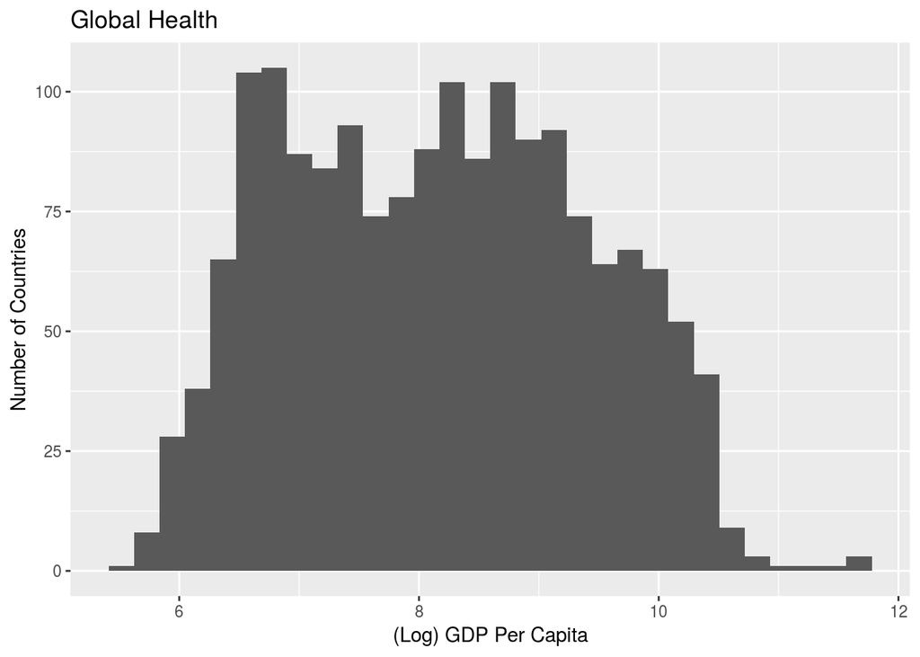

```r
ggplot(gapminder, mapping = aes(x = ln_gdpPercap)) +
  geom_histogram() +
  labs(title = "Global Health", x = "(Log) GDP Per Capita",
       y = "Number of Countries")
```